# Cuaderno de experimentos

En este cuaderno se registrará la evolución del trabajo cual si fuera un trabajo de campo.

# Problema: Como almacenar los mapas.

Es preciso encontrar una forma de interpretar los mapas para que la computadora pueda graficarlos. Encontramos que la librería “rgdal” que es capaz de procesar archivos .shp([ERSI Shapefile](https://es.wikipedia.org/wiki/Shapefile)) Graficarlo es tan sencillo como usar la función plot()

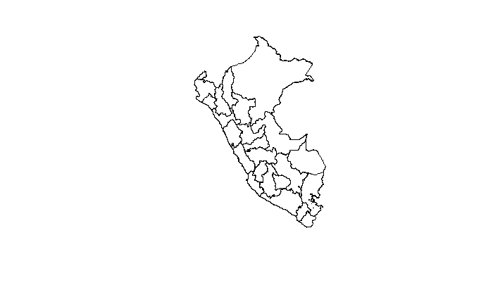

```r
mapa1 <- readOGR(file.choose())
plot(mapa1)
```

# Como colorear el mapa

El colorear el mapa también es cuestión de plot. Se requiere especificar el color de cada departamento en un array de enteros donde cada número representa un color.

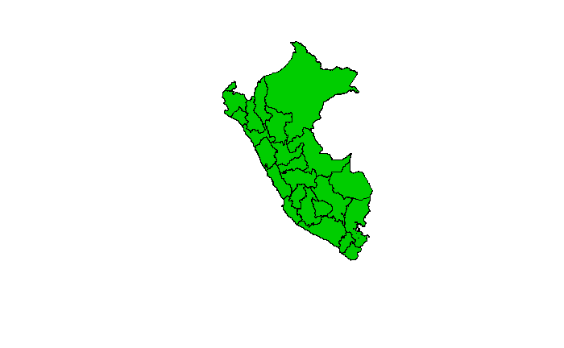

```r
plot(mapa1, col = rep(3, length(mapa1)))
```

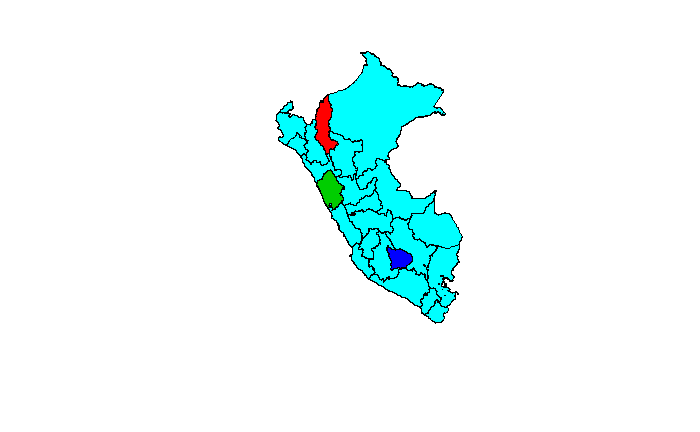

```r
plot(mapa1, col = c(2,3,4, rep(5, length(mapa1) - 3)))
```

# Problema crítico: Modelamiento

Ahora bien, el computador identifica las regiones y las colorea. Es de vital importancia para el proyecto que el computador identifique cuáles regiones son adyacentes a una región determinado. Por teoría de matemática discreta, la herramienta matemática que más se acopla a lo que deseamos es el grafo, debido a la posibilidad de representar las regiones como nodos conectados solamente si estás son adyacentes, y también por la teoría de coloración de grafos parcialmente estudiada en el curso de matemática discreta. Es preciso, pues, obtener la matriz de adyacencia del mapa.

## Calculo manual de la matriz de adyacencia

Para esto, buscamos los centros.

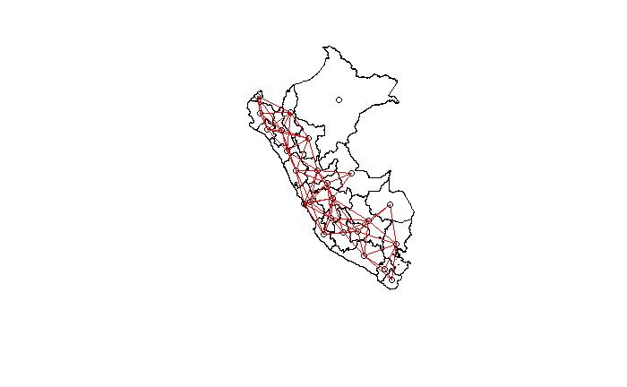

```r
centros <- coordinates(mapa1)
masProx <- knn2nb(knearneigh(centros))
ref <- quantile(unlist(nbdists(masProx, centros)),.99)
proxim <- dnearneigh(centros, 0, ref)
plot(mapa1)
plot(proxim, centros, add = TRUE, col = "red")
```

Vemos que realmente no hemos encontrado la matriz de adyacencia del mapa. *Intento fallido…*

## Calculo automático

Encontramos la librería “rgeos” que nos proporciona herramientas para llegar a la matriz de adyacencia de un mapa a partir del archivo .shp mediante la función gIntersects();

```r
adyacencia <- gIntersects(mapa1, byid=TRUE)## Matriz de adyacencia
adyacencia
```

```
       0     1     2     3     4     5     6     7     8     9    10    11    12    13    14
0   TRUE FALSE FALSE FALSE FALSE  TRUE FALSE FALSE FALSE FALSE FALSE FALSE  TRUE FALSE FALSE
1  FALSE  TRUE FALSE FALSE FALSE FALSE FALSE FALSE FALSE  TRUE FALSE FALSE  TRUE FALSE  TRUE
2  FALSE FALSE  TRUE  TRUE  TRUE FALSE FALSE  TRUE FALSE FALSE FALSE FALSE FALSE FALSE FALSE
3  FALSE FALSE  TRUE  TRUE  TRUE FALSE FALSE  TRUE FALSE FALSE  TRUE FALSE FALSE FALSE FALSE
4  FALSE FALSE  TRUE  TRUE  TRUE FALSE FALSE  TRUE  TRUE FALSE  TRUE  TRUE FALSE FALSE FALSE
5   TRUE FALSE FALSE FALSE FALSE  TRUE FALSE FALSE FALSE FALSE FALSE FALSE  TRUE  TRUE FALSE
6  FALSE FALSE FALSE FALSE FALSE FALSE  TRUE FALSE FALSE FALSE FALSE FALSE FALSE FALSE  TRUE
7  FALSE FALSE  TRUE  TRUE  TRUE FALSE FALSE  TRUE FALSE FALSE FALSE  TRUE FALSE FALSE FALSE
8  FALSE FALSE FALSE FALSE  TRUE FALSE FALSE FALSE  TRUE FALSE  TRUE  TRUE FALSE FALSE  TRUE
9  FALSE  TRUE FALSE FALSE FALSE FALSE FALSE FALSE FALSE  TRUE FALSE FALSE  TRUE FALSE  TRUE
10 FALSE FALSE FALSE  TRUE  TRUE FALSE FALSE FALSE  TRUE FALSE  TRUE FALSE FALSE FALSE  TRUE
11 FALSE FALSE FALSE FALSE  TRUE FALSE FALSE  TRUE  TRUE FALSE FALSE  TRUE FALSE FALSE  TRUE
12  TRUE  TRUE FALSE FALSE FALSE  TRUE FALSE FALSE FALSE  TRUE FALSE FALSE  TRUE  TRUE FALSE
13 FALSE FALSE FALSE FALSE FALSE  TRUE FALSE FALSE FALSE FALSE FALSE FALSE  TRUE  TRUE FALSE
```

[output cut: 37 more lines]

```r
# transformamos la matriz de adyacencia a una de 0 y 1
adyacencia[which(adyacencia == TRUE)] = 1
adyacencia
```

```
   0 1 2 3 4 5 6 7 8 9 10 11 12 13 14 15 16 17 18 19 20 21 22 23 24
0  1 0 0 0 0 1 0 0 0 0  0  0  1  0  0  1  0  0  0  0  0  1  0  0  0
1  0 1 0 0 0 0 0 0 0 1  0  0  1  0  1  0  0  0  0  0  0  0  0  0  0
2  0 0 1 1 1 0 0 1 0 0  0  0  0  0  0  0  0  0  0  0  0  0  0  0  0
3  0 0 1 1 1 0 0 1 0 0  1  0  0  0  0  0  0  1  0  0  1  0  0  0  0
4  0 0 1 1 1 0 0 1 1 0  1  1  0  0  0  0  0  0  0  0  0  0  0  0  0
5  1 0 0 0 0 1 0 0 0 0  0  0  1  1  0  0  0  0  0  1  0  0  0  0  0
6  0 0 0 0 0 0 1 0 0 0  0  0  0  0  1  0  0  0  0  0  0  0  0  0  0
7  0 0 1 1 1 0 0 1 0 0  0  1  0  0  0  0  1  0  0  0  1  0  0  0  1
8  0 0 0 0 1 0 0 0 1 0  1  1  0  0  1  0  0  0  0  0  0  0  0  0  0
9  0 1 0 0 0 0 0 0 0 1  0  0  1  0  1  1  0  0  1  0  0  1  0  0  1
10 0 0 0 1 1 0 0 0 1 0  1  0  0  0  1  0  0  0  0  0  0  0  0  0  0
11 0 0 0 0 1 0 0 1 1 0  0  1  0  0  1  0  0  0  1  0  0  0  0  0  1
12 1 1 0 0 0 1 0 0 0 1  0  0  1  1  0  0  0  0  0  0  0  1  0  0  0
13 0 0 0 0 0 1 0 0 0 0  0  0  1  1  0  0  0  0  0  1  0  0  0  0  0
14 0 1 0 0 0 0 1 0 1 1  1  1  0  0  1  0  0  0  1  0  0  0  0  0  0
15 1 0 0 0 0 0 0 0 0 1  0  0  0  0  0  1  0  0  0  0  0  1  0  0  1
16 0 0 0 0 0 0 0 1 0 0  0  0  0  0  0  0  1  0  0  0  1  0  0  0  1
17 0 0 0 1 0 0 0 0 0 0  0  0  0  0  0  0  0  1  0  0  1  0  1  0  0
18 0 0 0 0 0 0 0 0 0 1  0  1  0  0  1  0  0  0  1  0  0  0  0  0  1
19 0 0 0 0 0 1 0 0 0 0  0  0  0  1  0  0  0  0  0  1  0  0  0  1  0
20 0 0 0 1 0 0 0 1 0 0  0  0  0  0  0  0  1  1  0  0  1  0  1  0  0
21 1 0 0 0 0 0 0 0 0 1  0  0  1  0  0  1  0  0  0  0  0  1  0  0  0
22 0 0 0 0 0 0 0 0 0 0  0  0  0  0  0  0  0  1  0  0  1  0  1  0  0
23 0 0 0 0 0 0 0 0 0 0  0  0  0  0  0  0  0  0  0  1  0  0  0  1  0
24 0 0 0 0 0 0 0 1 0 1  0  1  0  0  0  1  1  0  1  0  0  0  0  0  1
```

## En busqueda de la función de coloración

Ahora es preciso encontrar la función que nos permita colorear el mapa con 4 colores. Elegimos el backtracking como primera opción.

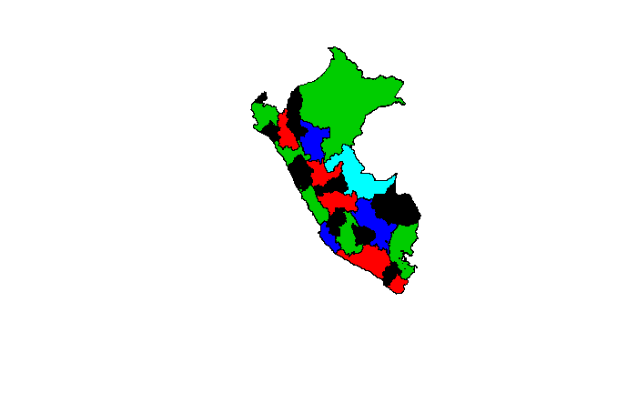

```r
color <- rep(0,length(mapa1))
correcto <- function(color, k) {
  if (k==1) return (TRUE)
  for(j in 1:(k-1)) {
    if(adyacencia[j,k]==1){  # comprueba que son adyacentes
      if(color[k]==color[j]) # comprueba que tienen el mismo color
        return(FALSE)
    }
  }
  return(TRUE)

}
# K recorre las columnas de adya y de color.
k=1
errores=0
while(k<=length(color)){
  color[k]=1
  while(!correcto(color,k)){ # mientras la asignacion de color sea inadecuada.
    color[k]=color[k]+1
    errores=errores+1;
  }
  if(errores==4) k=k-1
  k=k+1
}
plot(mapa1, col = color)
```